# Fig_ReadingProgressGraph

Pauliina Vuorinen

26/09/2022-20/12/2023

# Introduction

The purpose of this script is to create graphs about participants’ reading progress during the study. We plot reading location in text on the x-axis and time on the y-axis, with participants’ reading locations connected with lines in the graph. These graphs can tell us how linearly participants read the short story during the study and how far in the text the participants read.

## Setup

```r
library(dplyr)
library(tidyverse)
library(gridExtra)
```

```r
if (exists("ExternalAnalysisFilePath")) {
    # ExternalAnalysisFilePath: ~/Short_Story_Reading_Behaviour_Public/
    mypath_SSRB <- ExternalAnalysisFilePath
} else if (grepl("Fig", getwd())) {
    mypath_SSRB <- dirname(getwd())
} else if (grepl("Short_Story_Reading_Behaviour_Public", getwd())) {
    mypath_SSRB <- getwd()
} else {
    # get working directory manually
    mypath_SSRB <- paste0(
            dirname(getwd()),
            "/Short_Story_Reading_Behaviour_Public"
        )
}
```

## Load data

To create the timelines we use tracking data in which navigation blocks have been grouped together. This dataset was created and saved in Prep_TrackingDataWrangling.Rmd in Prep folder.

```r
grouped_navigation_blocks_data <-
    read.csv(
        paste0(
            mypath_SSRB,
            "/Data/wrangled_grouped_tracking_data.csv"
        ),
        header = TRUE,
        sep = ";",
        dec = ","
    )
grouped_navigation_blocks_data <- select(grouped_navigation_blocks_data, -X)
```

```r
str(grouped_navigation_blocks_data)
```

```
## 'data.frame':    3175 obs. of  97 variables:
##  $ X.1                            : int  6062 6063 6066 6067 6097 6099 6128 6129 6130 6131 ...
##  $ StoryId                        : int  7 7 7 7 7 7 7 7 7 7 ...
##  $ UserId                         : int  6 6 6 6 6 6 6 6 6 6 ...
##  $ ReadingSessionNumber           : int  4 4 4 4 4 4 4 4 4 4 ...
##  $ EngagementTypeId               : int  1 2 2 2 2 2 3 4 4 4 ...
##  $ Id                             : int  7784 7785 7788 7789 7819 7821 7850 7851 7852 7853 ...
##  $ NavigationBlockNumber          : int  27 28 29 30 31 32 33 34 35 36 ...
##  $ BaselineSpeed                  : num  320 320 320 320 320 ...
##  $ IsBaselineSpeedAdjusted        : logi  FALSE FALSE FALSE FALSE FALSE FALSE ...
##  $ AdjustedBaselineSpeed          : num  NA NA NA NA NA NA NA NA NA NA ...
##  $ IsIntrinsicCondition           : logi  FALSE FALSE FALSE FALSE FALSE FALSE ...
##  $ Date                           : chr  "2020-05-16" "2020-05-16" "2020-05-16" "2020-05-16" ...
##  $ Time                           : chr  "2022-09-29 11:03:13.290" "2022-09-29 11:03:14.109" "2022-09-29 11:03:21.053" "2022-09-29 11:03:21.409" ...
##  $ TimeBeforeDeadlinesDays        : num  3.99 3.99 3.99 3.99 3.98 ...
```

[output cut: 83 more lines]

```r
source(
    paste0(
        mypath_SSRB,
        "/Functions/Functions_VariableTypeConversion.R"
    )
)
## turn columns into factors that should be factors
grouped_navigation_blocks_data[, c(
    "UserId",
    "StoryId",
    "Direction",
    "NavigationBlockDirection"
)] <- convert.magic(
    grouped_navigation_blocks_data[, c(
        "UserId",
        "StoryId",
        "Direction",
        "NavigationBlockDirection"
    )],
    "factor"
)
## fix numeric columns that were automatically categorised as character
grouped_navigation_blocks_data[, c(
    "BaselineSpeed",
    "DurationMinutes",
    "ReadingBlockDuration",
    "EngagedReadingDuration",
    "EngagedReadingSpeed",
    "NavigationBlockDuration",
    "TimeBeforeDeadlinesDays",
    "NBEndLocation",
    "NBDuration"
)] <- convert.magic(
    grouped_navigation_blocks_data[, c(
        "BaselineSpeed",
        "DurationMinutes",
        "ReadingBlockDuration",
        "EngagedReadingDuration",
        "EngagedReadingSpeed",
        "NavigationBlockDuration",
        "TimeBeforeDeadlinesDays",
        "NBEndLocation",
        "NBDuration"
    )],
    "numeric"
)
## turn reading block (page view) number,
### reading session number, and
#### navigation block number into ordered factors
grouped_navigation_blocks_data[, c(
    "ReadingBlockNumber",
    "ReadingSessionNumber",
    "NavigationBlockNumber"
)] <- convert.magic(
    grouped_navigation_blocks_data[, c(
        "ReadingBlockNumber",
        "ReadingSessionNumber",
        "NavigationBlockNumber"
    )],
    "ordered"
)
## fix logical variables
grouped_navigation_blocks_data[, c(
    "IsBlurred",
    "IsDialogOpen",
    "IsMenuOpen",
    "IsInactive",
    "IsReading",
    "IsPageOpen"
)] <- convert.magic(
    grouped_navigation_blocks_data[, c(
        "IsBlurred",
        "IsDialogOpen",
        "IsMenuOpen",
        "IsInactive",
        "IsReading",
        "IsPageOpen"
    )],
    "logical"
)

## fix date and time variable types
grouped_navigation_blocks_data$Date <-
    as.Date(
        grouped_navigation_blocks_data$Date,
        format = "%Y-%m-%d"
    )
TempTimeObject <- strsplit(grouped_navigation_blocks_data$Time, " ")
TempTimeObject <- sapply(TempTimeObject, "[[", 2)
grouped_navigation_blocks_data$TempTimeObject <- TempTimeObject
grouped_navigation_blocks_data <- dplyr::select(grouped_navigation_blocks_data, -Time)
names(grouped_navigation_blocks_data)[which(colnames(grouped_navigation_blocks_data) == "TempTimeObject")] <- "Time"
grouped_navigation_blocks_data$DateTime <- paste(
    grouped_navigation_blocks_data$Date,
    grouped_navigation_blocks_data$Time
)
op <-
    options(digits.secs = 3)
grouped_navigation_blocks_data$Time <-
    strptime(
        grouped_navigation_blocks_data$Time,
        format = "%H:%M:%OS"
    )
grouped_navigation_blocks_data <- grouped_navigation_blocks_data %>%
    mutate(DateTime = as.POSIXct(DateTime, format = "%Y-%m-%d %H:%M:%OS"))
```

Sort the dataset:

```r
# order by User, date, time and event id
grouped_navigation_blocks_data <-
    grouped_navigation_blocks_data[
        with(
            grouped_navigation_blocks_data,
            order(UserId, Date, Time)
        ),
    ]
```

## Create a new dataset for the graph

To create the plot, we remove all events that don’t show engaged reading. Therefore, any events with no visible characters, and of which engagement type is ‘Disengagement’ or ‘Dialog’, are removed. We then calculate the cumulative engagement duration for these events and transform the dataset into longer format.

First, we create a variable that shows location in percentages at the beginning and end of each navigation block.

```r
grouped_navigation_blocks_data$NBFirstPercentage <- (
    grouped_navigation_blocks_data$NBFirstStartLocation
        / grouped_navigation_blocks_data$CharacterLength
)
grouped_navigation_blocks_data$NBLastPercentage <- (
    grouped_navigation_blocks_data$NBEndLocation
        / grouped_navigation_blocks_data$CharacterLength
)
```

Next, we create the subset dataset. We want to remove events with no visible characters and events that are disengagements or dialog events. We then count cumulative duration for these events. The dataset is then reorganised into a longer format in which the first location in a navigation block is differentiated from the last location in a navigation block. Therefore, each navigation block is turned into two events.

```r
graph_subset_data <- grouped_navigation_blocks_data %>%
    filter(
        (VisibleCharacterCount != 0) &
            (Engagement != "Disengagement") &
            (Engagement != "Dialog")
    ) %>%
    group_by(UserId) %>%
    mutate(
        CumulativeDuration = cumsum(NBDuration)
    ) %>%
    pivot_longer(c(NBFirstPercentage, NBLastPercentage),
        names_to = "Point",
        values_to = "Per"
    ) %>%
    select(
        UserId,
        StoryId,
        DateTime,
        NavigationBlockNumber,
        Condition,
        Date,
        Time,
        Point,
        Per,
        CumulativeDuration,
        CharacterLength
    )
```

We then create tests that will be useful:

```r
# order by User, date, time and event id
graph_subset_data <-
    graph_subset_data[
        with(
            graph_subset_data,
            order(UserId, Date, Time)
        ),
    ]
# create tests
graph_subset_data$IsNewUser <- (
    graph_subset_data$UserId != lag(graph_subset_data$UserId, 1)
)
# set the first IsNewUser value to TRUE
graph_subset_data[is.na(graph_subset_data$IsNewUser), ]$IsNewUser <- TRUE
```

Finally, we create a duration variable that is used in the plot.

```r
# order by User, date, time and event id
graph_subset_data <-
    graph_subset_data[
        with(
            graph_subset_data,
            order(UserId, Date, Time)
        ),
    ]
# Calculate durations for graph
graph_subset_data$GraphDuration <- ifelse(
    # a navigation block from a new user
    (graph_subset_data$Point == "NBFirstPercentage" &
        graph_subset_data$IsNewUser),
    0,
    ifelse(
        # a navigation block from the same user as previous
        (graph_subset_data$Point == "NBFirstPercentage" &
            !graph_subset_data$IsNewUser),
        lag(graph_subset_data$CumulativeDuration, 1),
        ifelse(
            # the last event in a navigation block
            graph_subset_data$Point == "NBLastPercentage",
            graph_subset_data$CumulativeDuration,
            NA
        )
    )
)
```

## Progress graph

### 1. A progress graph for each participant

```r
Graph1a <- ggplot(
    graph_subset_data,
    aes(
        x = GraphDuration,
        y = Per * 100,
        colour = UserId
    )
)
```

```r
Graph1b <- Graph1a +
    geom_line(size = .9) +
    labs(
        y = "Location in Story (%)",
        x = "Cumulative time spent reading (min)",
    ) +
    coord_cartesian(xlim = c(0, 150), ylim = c(0, 120), expand = FALSE) +
    facet_wrap(~UserId) +
    scale_y_continuous(breaks = c(50, 100)) +
    scale_x_continuous(breaks = c(0, 50, 100))
```

```r
Graph1c <- Graph1b +
    theme_bw() +
    theme(
        panel.grid.major = element_line(
            colour = "#a6a6a6",
            size = 0.1,
            linetype = "solid"
        ),
        legend.position = "none",
        panel.grid.minor = element_blank(),
        axis.text.x = element_text(size = 20),
        axis.text.y = element_text(size = 20),
        axis.ticks = element_blank(),
        axis.title.x = element_text(size = 20, vjust = 0.5),
        axis.title.y = element_text(size = 20, angle = 90, vjust = 0.5),
        legend.text = element_text(size = 12),
        legend.title = element_text(size = 15),
        strip.background = element_blank(),
        plot.title = element_text(size = 20, hjust = .5),
        strip.text.x = element_blank()
    )
```

```r
Graph1d <- Graph1c +
    coord_flip(
        ylim = c(0, 100),
        xlim = c(0, 130)
    )
```

```
## will replace the existing one.
```

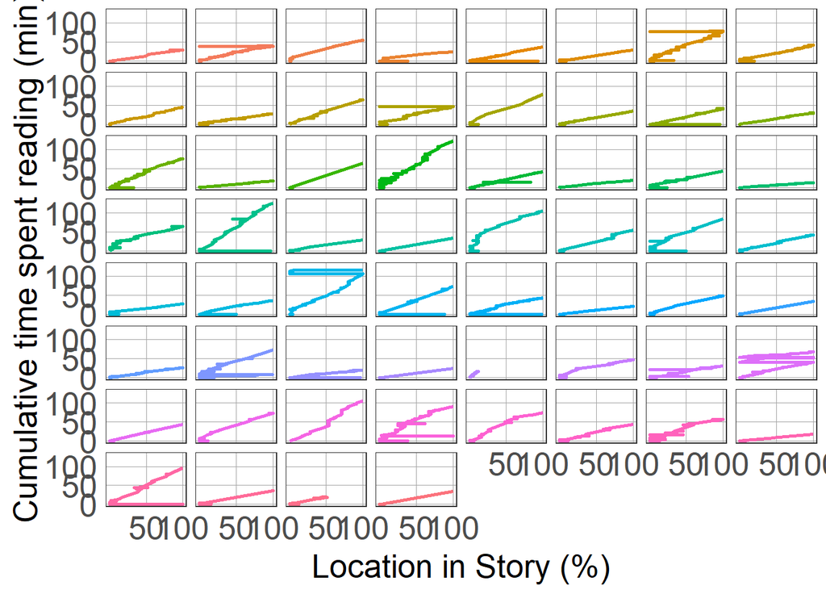

```r
Graph1d
```

We then save the progress graph grouped by participant indicator. The figure has already been saved and so the below code is not run. The figure can be found in Fig folder as Fig_ProgressGraphGroupedByParticipant.png

```r
# ggsave(
#     "Fig_ProgressGraphGroupedByParticipant.png",
#     plot = Graph1d,
#     width = 27,
#     height = 20,
#     units = "cm",
#     dpi = 300
# )
```

### 2. A progress graph for participants in the high-autonomy and low-autonomy conditions

```r
Graph2a <- ggplot(
    graph_subset_data,
    aes(
        x = GraphDuration,
        y = Per * 100,
        colour = UserId
    )
)
```

```r
graph_subset_data$Condition <- dplyr::recode(
    graph_subset_data$Condition,
    "AutonomousCondition" = "High-Autonomy Condition",
    "NonAutonomousCondition" = "Low-Autonomy Condition"
)
```

```r
Graph2b <- Graph2a +
    geom_line(size = .9) +
    labs(
        y = "Location in Story (%)",
        x = "Cumulative time spent reading (min)",
    ) +
    coord_cartesian(xlim = c(0, 150), ylim = c(0, 120), expand = FALSE) +
    facet_wrap(~Condition) +
    scale_y_continuous(breaks = c(50, 100)) +
    scale_x_continuous(breaks = c(0, 50, 100))
```

```r
Graph2c <- Graph2b +
    theme_bw() +
    theme(
        panel.grid.major = element_line(
            colour = "#a6a6a6",
            size = 0.1,
            linetype = "solid"
        ),
        legend.position = "none",
        panel.grid.minor = element_blank(),
        axis.text.x = element_text(size = 20),
        axis.text.y = element_text(size = 20),
        axis.ticks = element_blank(),
        axis.title.x = element_text(size = 20, vjust = 0.5),
        axis.title.y = element_text(size = 20, angle = 90, vjust = 0.5),
        legend.text = element_text(size = 12),
        legend.title = element_text(size = 15),
        strip.background = element_blank(),
        plot.title = element_text(size = 20, hjust = .5),
        strip.text = element_text(size = 16)
    )
```

```r
Graph2d <- Graph2c +
    coord_flip(
        ylim = c(0, 100),
        xlim = c(0, 130)
    )
```

```
## will replace the existing one.
```

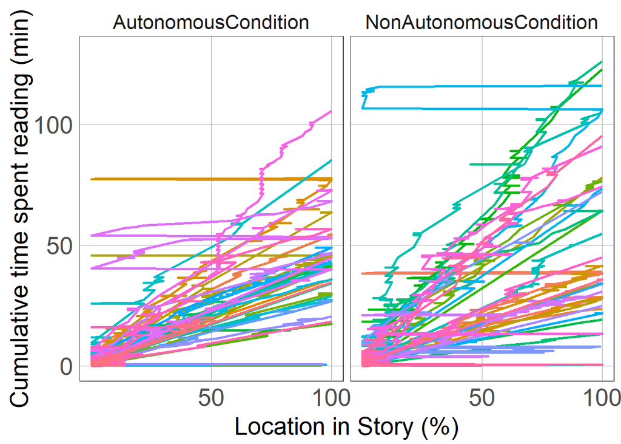

```r
Graph2d
```

We then save the progress graph grouped by condition. The figure has already been saved and so the below code is not run. The figure can be found in Fig folder as Fig_ProgressGraphGroupedByCondition.png

```r
# ggsave(
#     "Fig_ProgressGraphGroupedByCondition.png",
#     plot = Graph2d,
#     width = 20,
#     height = 20,
#     units = "cm",
#     dpi = 300
# )
```

### 3. Progress graphs for participants in each short story group

A progress graph is created for each short story group separately so that we can add a chronological line to which linearity can be compared.

The following function will be needed for all story progress graphs:

```r
source(
    paste0(
        mypath_SSRB,
        "/Functions/Functions_AddLine.R"
    )
)
```

#### StoryId 1

```r
StoryId1 <- filter(graph_subset_data, StoryId == "1")
```

```r
Graph31a <- ggplot(
    StoryId1,
    aes(
        x = GraphDuration,
        y = Per * 100,
        color = UserId
    )
)
```

```r
Graph31b <- Graph31a +
    geom_line(size = .9) +
    labs(
        y = "Location in Story (%)",
        title = "Story 1",
        x = addline_format("Cumulative time spent,reading (min)"),
    ) +
    coord_cartesian(xlim = c(0, 150), ylim = c(0, 120), expand = FALSE) +
    scale_y_continuous(breaks = c(50, 100)) +
    scale_x_continuous(breaks = c(0, 50, 100))
```

```r
ChronologicalAblineStoryId1 <- data.frame(
    "intercept" = 0,
    # slope value is (100/((character length/5)/population average speed))
    "slope" = (100 / ((unique(StoryId1$CharacterLength) / 5) / 260)),
    "label" = "Chronological"
)
```

```r
Graph31c <- Graph31b +
    geom_abline(
        data = ChronologicalAblineStoryId1,
        aes(
            intercept = intercept,
            slope = slope,
            colour = label,
            linetype = "longdash"
        ),
        size = 1,
        colour = "black"
    )
```

```r
Graph31d <- Graph31b +
    theme_bw() +
    theme(
        panel.grid.major = element_line(
            colour = "#a6a6a6",
            size = 0.1,
            linetype = "solid"
        ),
        legend.position = "none",
        panel.grid.minor = element_blank(),
        axis.text.x = element_text(size = 20),
        axis.text.y = element_text(size = 20),
        axis.ticks = element_blank(),
        axis.title.x = element_text(size = 20, vjust = 0.5),
        axis.title.y = element_text(size = 20, angle = 90, vjust = 0.5),
        legend.text = element_text(size = 12),
        legend.title = element_text(size = 15),
        plot.title = element_text(size = 20, hjust = .5)
    )
```

```r
Graph31e <- Graph31d +
    coord_flip(
        ylim = c(0, 100),
        xlim = c(0, 130)
    )
```

```
## will replace the existing one.
```

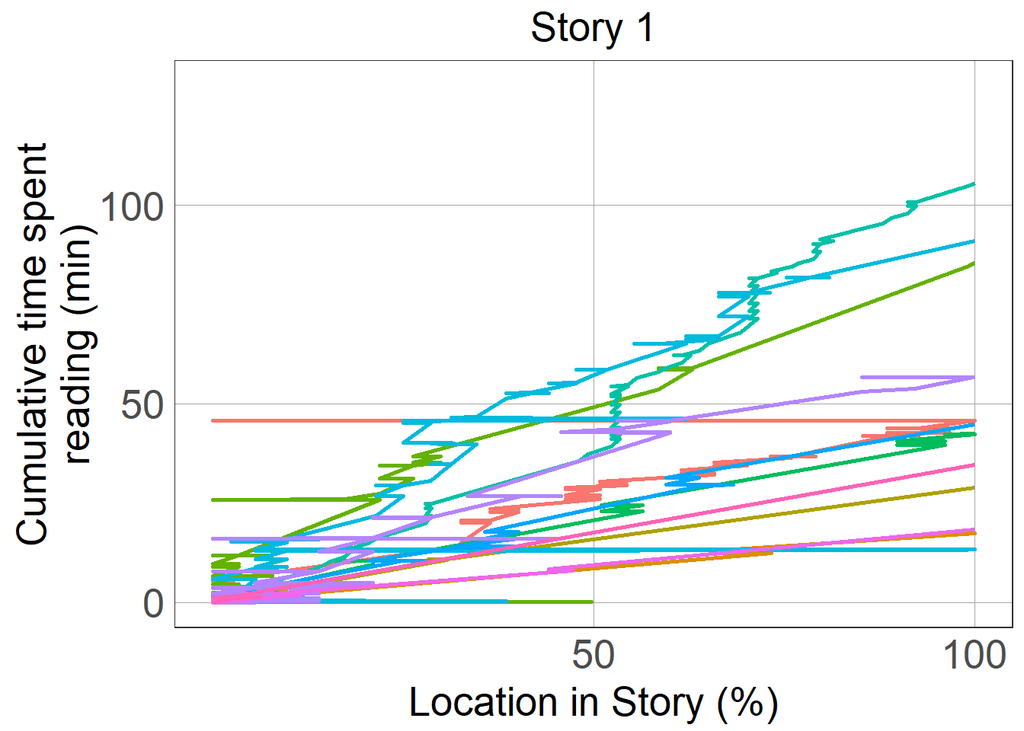

```r
Graph31e
```

#### StoryId 2

```r
StoryId2 <- filter(graph_subset_data, StoryId == "2")
```

```r
Graph32a <- ggplot(
    StoryId2,
    aes(
        x = GraphDuration,
        y = Per * 100,
        colour = UserId
    )
)
```

```r
Graph32b <- Graph32a +
    geom_line(size = .9) +
    labs(
        y = "Location in Story (%)",
        title = "Story 2",
        x = addline_format("Cumulative time spent,reading (min)"),
    ) +
    coord_cartesian(xlim = c(0, 150), ylim = c(0, 120), expand = FALSE) +
    scale_y_continuous(breaks = c(50, 100)) +
    scale_x_continuous(breaks = c(0, 50, 100))
```

```r
ChronologicalAblineStoryId2 <- data.frame(
    "intercept" = 0,
    # slope value is (100/((character length/5)/population average speed))
    "slope" = (100 / ((unique(StoryId2$CharacterLength) / 5) / 260)),
    "label" = "Chronological"
)
```

```r
Graph32c <- Graph32b +
    geom_abline(
        data = ChronologicalAblineStoryId2,
        aes(
            intercept = intercept,
            slope = slope,
            colour = label,
            linetype = "longdash"
        ),
        size = 1,
        colour = "black"
    )
```

```r
Graph32d <- Graph32c +
    theme_bw() +
    theme(
        panel.grid.major = element_line(
            colour = "#a6a6a6",
            size = 0.1,
            linetype = "solid"
        ),
        panel.grid.minor = element_blank(),
        legend.position = "none",
        axis.text.x = element_text(size = 20),
        axis.text.y = element_text(size = 20),
        axis.ticks = element_blank(),
        axis.title.x = element_text(size = 20, vjust = 0.5),
        axis.title.y = element_text(size = 20, angle = 90, vjust = 0.5),
        legend.text = element_text(size = 12),
        legend.title = element_text(size = 15),
        plot.title = element_text(size = 20, hjust = .5)
    )
```

```r
Graph32e <- Graph32d +
    coord_flip(
        ylim = c(0, 100),
        xlim = c(0, 130)
    )
```

```
## will replace the existing one.
```

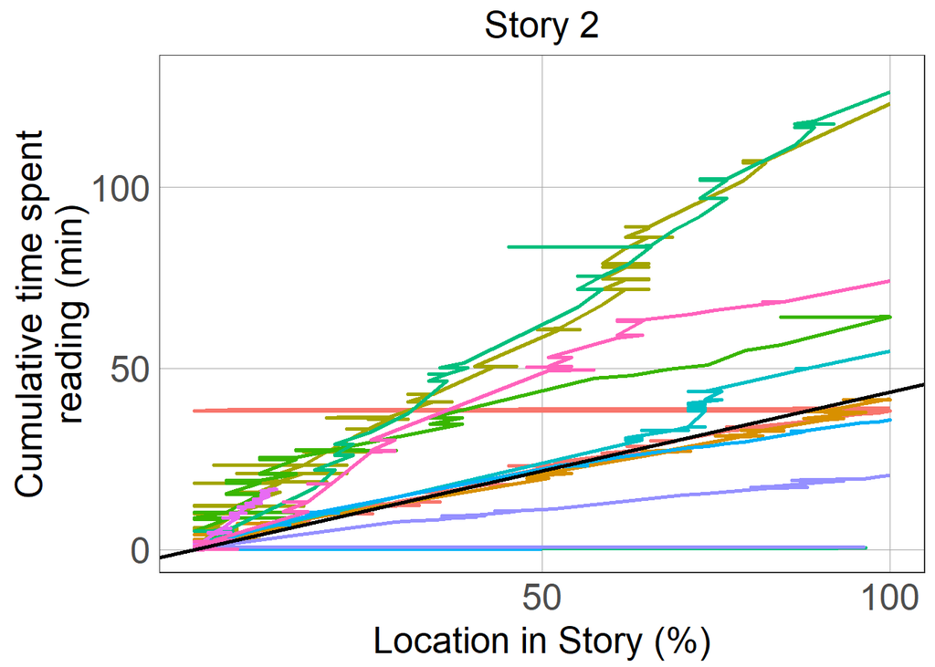

```r
Graph32e
```

#### StoryId 3

```r
StoryId3 <- filter(graph_subset_data, StoryId == "3")
```

```r
Graph33a <- ggplot(
    StoryId3,
    aes(
        x = GraphDuration,
        y = Per * 100,
        colour = UserId
    )
)
```

```r
Graph33b <- Graph33a +
    geom_line(size = .9) +
    labs(
        y = "Location in Story (%)",
        title = "Story 3",
        x = addline_format("Cumulative time spent,reading (min)"),
    ) +
    coord_cartesian(xlim = c(0, 150), ylim = c(0, 120), expand = FALSE) +
    scale_y_continuous(breaks = c(50, 100)) +
    scale_x_continuous(breaks = c(0, 50, 100))
```

```r
ChronologicalAblineStoryId3 <- data.frame(
    "intercept" = 0,
    # slope value is (100/((character length/5)/population average speed))
    "slope" = (100 / ((unique(StoryId3$CharacterLength) / 5) / 260)),
    "label" = "Chronological"
)
```

```r
Graph33c <- Graph33b +
    geom_abline(
        data = ChronologicalAblineStoryId3,
        aes(
            intercept = intercept,
            slope = slope,
            colour = label,
            linetype = "longdash"
        ),
        size = 1,
        colour = "black"
    )
```

```r
Graph33d <- Graph33c +
    theme_bw() +
    theme(
        panel.grid.major = element_line(
            colour = "#a6a6a6",
            size = 0.1,
            linetype = "solid"
        ),
        panel.grid.minor = element_blank(),
        legend.position = "none",
        axis.text.x = element_text(size = 20),
        axis.text.y = element_text(size = 20),
        axis.ticks = element_blank(),
        axis.title.x = element_text(size = 20, vjust = 0.5),
        axis.title.y = element_text(size = 20, angle = 90, vjust = 0.5),
        legend.text = element_text(size = 12),
        legend.title = element_text(size = 15),
        plot.title = element_text(size = 20, hjust = .5)
    )
```

```r
Graph33e <- Graph33d +
    coord_flip(
        ylim = c(0, 100),
        xlim = c(0, 130)
    )
```

```
## will replace the existing one.
```

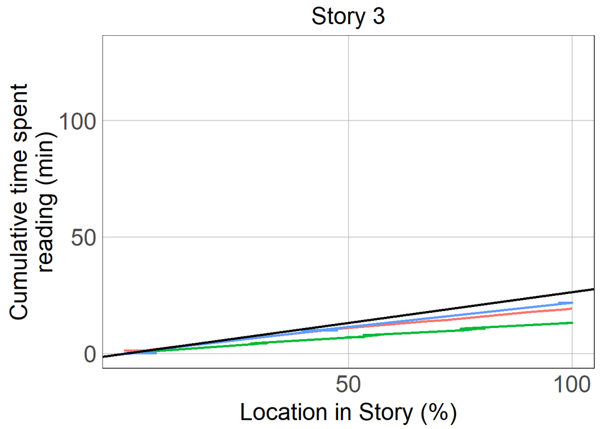

```r
Graph33e
```

#### StoryId 4

```r
StoryId4 <- filter(graph_subset_data, StoryId == "4")
```

```r
Graph34a <- ggplot(
    StoryId4,
    aes(
        x = GraphDuration,
        y = Per * 100,
        colour = UserId
    )
)
```

```r
Graph34b <- Graph34a +
    geom_line(size = .9) +
    labs(
        y = "Location in Story (%)",
        title = "Story 4",
        x = addline_format("Cumulative time spent,reading (min)"),
    ) +
    coord_cartesian(xlim = c(0, 150), ylim = c(0, 120), expand = FALSE) +
    scale_y_continuous(breaks = c(50, 100)) +
    scale_x_continuous(breaks = c(0, 50, 100))
```

```r
ChronologicalAblineStoryId4 <- data.frame(
    "intercept" = 0,
    # slope value is (100/((character length/5)/population average speed))
    "slope" = (100 / ((unique(StoryId4$CharacterLength) / 5) / 260)),
    "label" = "Chronological"
)
```

```r
Graph34c <- Graph34b +
    geom_abline(
        data = ChronologicalAblineStoryId4,
        aes(
            intercept = intercept,
            slope = slope,
            colour = label,
            linetype = "longdash"
        ),
        size = 1,
        colour = "black"
    )
```

```r
Graph34d <- Graph34c +
    theme_bw() +
    theme(
        panel.grid.major = element_line(
            colour = "#a6a6a6",
            size = 0.1,
            linetype = "solid"
        ),
        panel.grid.minor = element_blank(),
        legend.position = "none",
        axis.text.x = element_text(size = 20),
        axis.text.y = element_text(size = 20),
        axis.ticks = element_blank(),
        axis.title.x = element_text(size = 20, vjust = 0.5),
        axis.title.y = element_text(size = 20, angle = 90, vjust = 0.5),
        legend.text = element_text(size = 12),
        legend.title = element_text(size = 15),
        plot.title = element_text(size = 20, hjust = .5)
    )
```

```r
Graph34e <- Graph34d +
    coord_flip(
        ylim = c(0, 100),
        xlim = c(0, 130)
    )
```

```
## will replace the existing one.
```

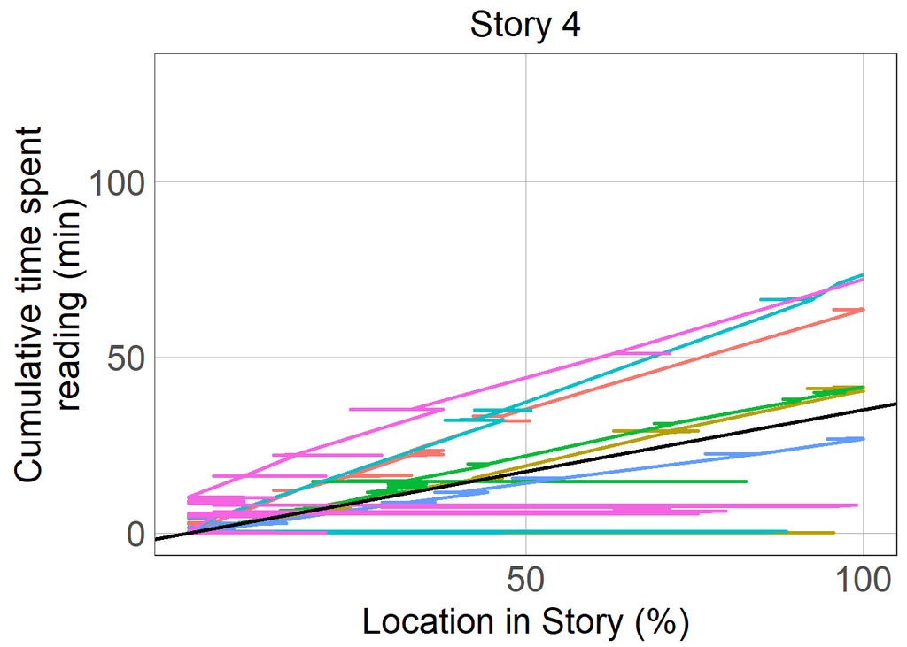

```r
Graph34e
```

#### StoryId 5

```r
StoryId5 <- filter(graph_subset_data, StoryId == "5")
```

```r
Graph35a <- ggplot(
    StoryId5,
    aes(
        x = GraphDuration,
        y = Per * 100,
        colour = UserId
    )
)
```

```r
Graph35b <- Graph35a +
    geom_line(size = .9) +
    labs(
        y = "Location in Story (%)",
        title = "Story 5",
        x = addline_format("Cumulative time spent,reading (min)"),
    ) +
    coord_cartesian(xlim = c(0, 150), ylim = c(0, 120), expand = FALSE) +
    scale_y_continuous(breaks = c(50, 100)) +
    scale_x_continuous(breaks = c(0, 50, 100))
```

```r
ChronologicalAblineStoryId5 <- data.frame(
    "intercept" = 0,
    # slope value is (100/((character length/5)/population average speed))
    "slope" = (100 / ((unique(StoryId5$CharacterLength) / 5) / 260)),
    "label" = "Chronological"
)
```

```r
Graph35c <- Graph35b +
    geom_abline(
        data = ChronologicalAblineStoryId5,
        aes(
            intercept = intercept,
            slope = slope,
            colour = label,
            linetype = "longdash"
        ),
        size = 1,
        colour = "black"
    )
```

```r
Graph35d <- Graph35c +
    theme_bw() +
    theme(
        panel.grid.major = element_line(
            colour = "#a6a6a6",
            size = 0.1,
            linetype = "solid"
        ),
        panel.grid.minor = element_blank(),
        legend.position = "none",
        axis.text.x = element_text(size = 20),
        axis.text.y = element_text(size = 20),
        axis.ticks = element_blank(),
        axis.title.x = element_text(size = 20, vjust = 0.5),
        axis.title.y = element_text(size = 20, angle = 90, vjust = 0.5),
        legend.text = element_text(size = 12),
        legend.title = element_text(size = 15),
        plot.title = element_text(size = 20, hjust = .5)
    )
```

```r
Graph35e <- Graph35d +
    coord_flip(
        ylim = c(0, 100),
        xlim = c(0, 130)
    )
```

```
## will replace the existing one.
```

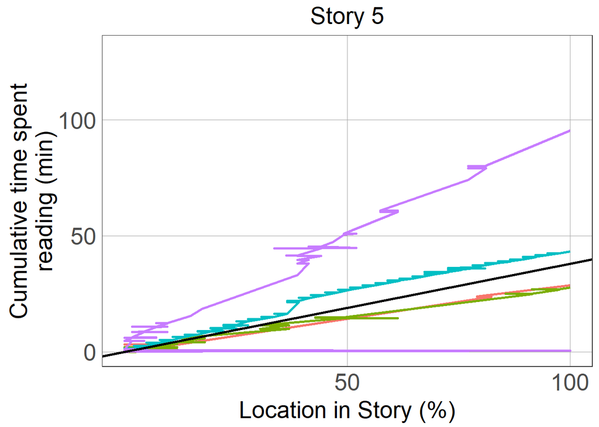

```r
Graph35e
```

#### StoryId 6

```r
StoryId6 <- filter(graph_subset_data, StoryId == "6")
```

```r
Graph36a <- ggplot(
    StoryId6,
    aes(
        x = GraphDuration,
        y = Per * 100,
        colour = UserId
    )
)
```

```r
Graph36b <- Graph36a +
    geom_line(size = .9) +
    labs(
        y = "Location in Story (%)",
        title = "Story 6",
        x = addline_format("Cumulative time spent,reading (min)"),
    ) +
    coord_cartesian(xlim = c(0, 150), ylim = c(0, 120), expand = FALSE) +
    scale_y_continuous(breaks = c(50, 100)) +
    scale_x_continuous(breaks = c(0, 50, 100))
```

```r
ChronologicalAblineStoryId6 <- data.frame(
    "intercept" = 0,
    # slope value is (100/((character length/5)/population average speed))
    "slope" = (100 / ((unique(StoryId6$CharacterLength) / 5) / 260)),
    "label" = "Chronological"
)
```

```r
Graph36c <- Graph36b +
    geom_abline(
        data = ChronologicalAblineStoryId6,
        aes(
            intercept = intercept,
            slope = slope,
            colour = label,
            linetype = "longdash"
        ),
        size = 1,
        colour = "black"
    )
```

```r
Graph36d <- Graph36c +
    theme_bw() +
    theme(
        panel.grid.major = element_line(
            colour = "#a6a6a6",
            size = 0.1,
            linetype = "solid"
        ),
        panel.grid.minor = element_blank(),
        legend.position = "none",
        axis.text.x = element_text(size = 20),
        axis.text.y = element_text(size = 20),
        axis.ticks = element_blank(),
        axis.title.x = element_text(size = 20, vjust = 0.5),
        axis.title.y = element_text(size = 20, angle = 90, vjust = 0.5),
        legend.text = element_text(size = 12),
        legend.title = element_text(size = 15),
        plot.title = element_text(size = 20, hjust = .5)
    )
```

```r
Graph36e <- Graph36d +
    coord_flip(
        ylim = c(0, 100),
        xlim = c(0, 130)
    )
```

```
## will replace the existing one.
```

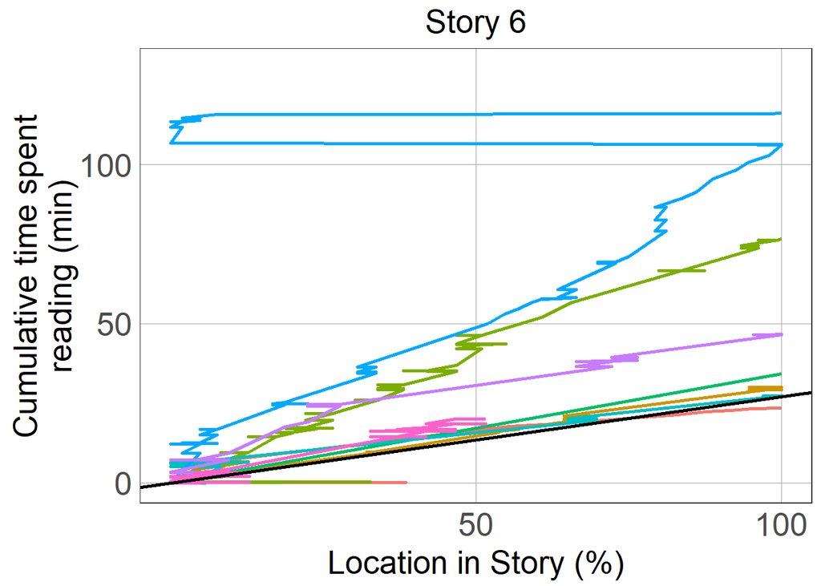

```r
Graph36e
```

#### StoryId 7

```r
StoryId7 <- filter(graph_subset_data, StoryId == "7")
```

```r
Graph37a <- ggplot(
    StoryId7,
    aes(
        x = GraphDuration,
        y = Per * 100,
        colour = UserId
    )
)
```

```r
Graph37b <- Graph37a +
    geom_line(size = .9) +
    labs(
        y = "Location in Story (%)",
        title = "Story 7",
        x = addline_format("Cumulative time spent,reading (min)"),
    ) +
    coord_cartesian(xlim = c(0, 150), ylim = c(0, 120), expand = FALSE) +
    scale_y_continuous(breaks = c(50, 100)) +
    scale_x_continuous(breaks = c(0, 50, 100))
```

```r
ChronologicalAblineStoryId7 <- data.frame(
    "intercept" = 0,
    # slope value is (100/((character length/5)/population average speed))
    "slope" = (100 / ((unique(StoryId7$CharacterLength) / 5) / 260)),
    "label" = "Chronological"
)
```

```r
Graph37c <- Graph37b +
    geom_abline(
        data = ChronologicalAblineStoryId7,
        aes(
            intercept = intercept,
            slope = slope,
            colour = label,
            linetype = "longdash"
        ),
        size = 1,
        colour = "black"
    )
```

```r
Graph37d <- Graph37c +
    theme_bw() +
    theme(
        panel.grid.major = element_line(
            colour = "#a6a6a6",
            size = 0.1,
            linetype = "solid"
        ),
        panel.grid.minor = element_blank(),
        legend.position = "none",
        axis.text.x = element_text(size = 20),
        axis.text.y = element_text(size = 20),
        axis.ticks = element_blank(),
        axis.title.x = element_text(size = 20, vjust = 0.5),
        axis.title.y = element_text(size = 20, angle = 90, vjust = 0.5),
        legend.text = element_text(size = 12),
        legend.title = element_text(size = 15),
        plot.title = element_text(size = 20, hjust = .5)
    )
```

```r
Graph37e <- Graph37d +
    coord_flip(
        ylim = c(0, 100),
        xlim = c(0, 130)
    )
```

```
## will replace the existing one.
```

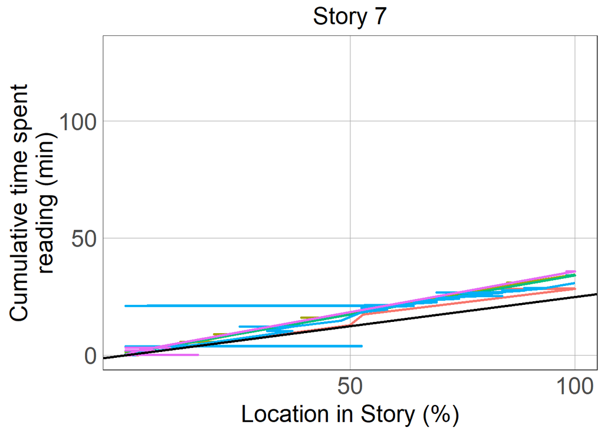

```r
Graph37e
```

#### StoryId 8

```r
StoryId8 <- filter(graph_subset_data, StoryId == "8")
```

```r
Graph38a <- ggplot(
    StoryId8,
    aes(
        x = GraphDuration,
        y = Per * 100,
        colour = UserId
    )
)
```

```r
Graph38b <- Graph38a +
    geom_line(size = .9) +
    labs(
        y = "Location in Story (%)",
        title = "Story 8",
        x = addline_format("Cumulative time spent,reading (min)"),
    ) +
    coord_cartesian(xlim = c(0, 150), ylim = c(0, 120), expand = FALSE) +
    scale_y_continuous(breaks = c(50, 100)) +
    scale_x_continuous(breaks = c(0, 50, 100))
```

```r
ChronologicalAblineStoryId8 <- data.frame(
    "intercept" = 0,
    # slope value is (100/((character length/5)/population average speed))
    "slope" = (100 / ((unique(StoryId8$CharacterLength) / 5) / 260)),
    "label" = "Chronological"
)
```

```r
Graph38c <- Graph38b +
    geom_abline(
        data = ChronologicalAblineStoryId8,
        aes(
            intercept = intercept,
            slope = slope,
            colour = label,
            linetype = "longdash"
        ),
        size = 1,
        colour = "black"
    )
```

```r
Graph38d <- Graph38c +
    theme_bw() +
    theme(
        panel.grid.major = element_line(
            colour = "#a6a6a6",
            size = 0.1,
            linetype = "solid"
        ),
        panel.grid.minor = element_blank(),
        legend.position = "none",
        axis.text.x = element_text(size = 20),
        axis.text.y = element_text(size = 20),
        axis.ticks = element_blank(),
        axis.title.x = element_text(size = 20, vjust = 0.5),
        axis.title.y = element_text(size = 20, angle = 90, vjust = 0.5),
        legend.text = element_text(size = 12),
        legend.title = element_text(size = 15),
        plot.title = element_text(size = 20, hjust = .5)
    )
```

```r
Graph38e <- Graph38d +
    coord_flip(
        ylim = c(0, 100),
        xlim = c(0, 130)
    )
```

```
## will replace the existing one.
```

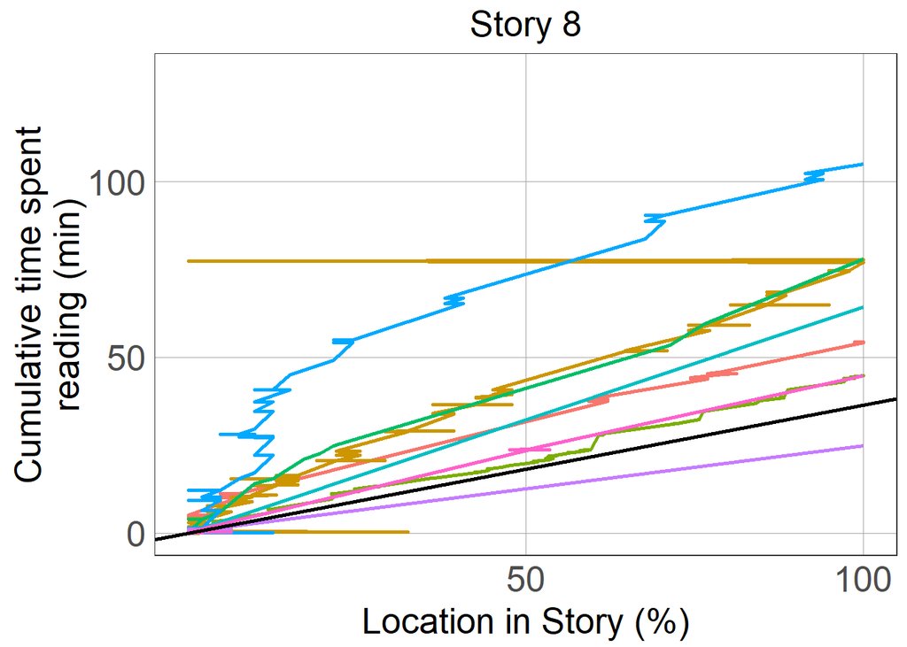

```r
Graph38e
```

#### StoryId 9

```r
StoryId9 <- filter(graph_subset_data, StoryId == "9")
```

```r
Graph39a <- ggplot(
    StoryId9,
    aes(
        x = GraphDuration,
        y = Per * 100,
        colour = UserId
    )
)
```

```r
Graph39b <- Graph39a +
    geom_line(size = .9) +
    labs(
        y = "Location in Story (%)",
        title = "Story 9",
        x = addline_format("Cumulative time spent,reading (min)"),
    ) +
    coord_cartesian(xlim = c(0, 150), ylim = c(0, 120), expand = FALSE) +
    scale_y_continuous(breaks = c(50, 100)) +
    scale_x_continuous(breaks = c(0, 50, 100))
```

```r
ChronologicalAblineStoryId9 <- data.frame(
    "intercept" = 0,
    # slope value is (100/((character length/5)/population average speed))
    "slope" = (100 / ((unique(StoryId9$CharacterLength) / 5) / 260)),
    "label" = "Chronological"
)
```

```r
Graph39c <- Graph39b +
    geom_abline(
        data = ChronologicalAblineStoryId9,
        aes(
            intercept = intercept,
            slope = slope,
            colour = label,
            linetype = "longdash"
        ),
        size = 1,
        colour = "black"
    )
```

```r
Graph39d <- Graph39c +
    theme_bw() +
    theme(
        panel.grid.major = element_line(
            colour = "#a6a6a6",
            size = 0.1,
            linetype = "solid"
        ),
        panel.grid.minor = element_blank(),
        legend.position = "none",
        axis.text.x = element_text(size = 20),
        axis.text.y = element_text(size = 20),
        axis.ticks = element_blank(),
        axis.title.x = element_text(size = 20, vjust = 0.5),
        axis.title.y = element_text(size = 20, angle = 90, vjust = 0.5),
        legend.text = element_text(size = 12),
        legend.title = element_text(size = 15),
        plot.title = element_text(size = 20, hjust = .5)
    )
```

```r
Graph39e <- Graph39d +
    coord_flip(
        ylim = c(0, 100),
        xlim = c(0, 130)
    )
```

```
## will replace the existing one.
```

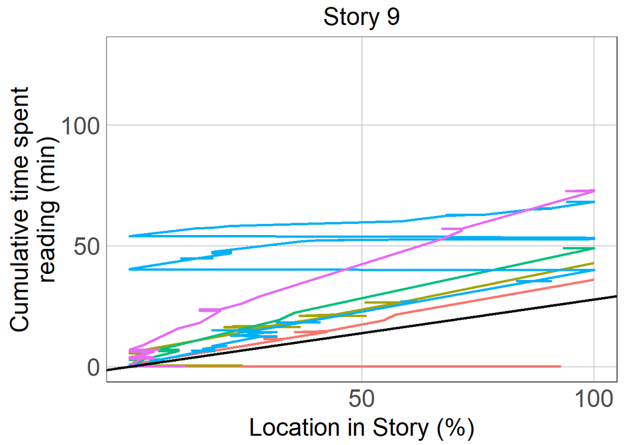

```r
Graph39e
```

##### Combine Story Graphs

We combine the story graphs into one graph

[figure not shown]

```r
StoryGraph <- grid.arrange(
    Graph31e,
    Graph32e,
    Graph33e,
    Graph34e,
    Graph35e,
    Graph36e,
    Graph37e,
    Graph38e,
    Graph39e,
    ncol = 2
)
```

We then save the story progress graph. The below code has already been run and the figure can be found as in Fig folder as Fig_ProgressGraphGroupedByStory.png

```r
# ggsave(
#     "Fig_ProgressGraphGroupedByStory.png",
#     plot = StoryGraph,
#     width = 20,
#     height = 50,
#     units = "cm",
#     dpi = 300
# )
```

## 4. Progress graphs for one story with 4 random participants

This graph is made for illustration purposes to be used in the manuscript. First, we find which stories have the highest number of participants:

```r
participant_story_count <- grouped_navigation_blocks_data %>%
    group_by(StoryId) %>%
    summarise(
        ParticipantCount = length(unique(UserId))
    )
```

StoryId 1 has 11 participants, and so we use StoryId 1.

```r
StoryId1 <- filter(graph_subset_data, StoryId == "1")
```

Randomly select four participants who read StoryId 1:

```r
set.seed(888)
four_participants <- sample(unique(StoryId1$UserId), 4)
```

```r
StoryId1_sample <- filter(StoryId1, UserId %in% four_participants)
```

```r
Graph4a <- ggplot(
    StoryId1_sample,
    aes(
        x = GraphDuration,
        y = Per * 100,
        group = UserId
    )
)
```

```r
Graph4b <- Graph4a +
    geom_line(size = .9,  aes(colour = UserId)) +
    labs(
        y = "Location in Story (%)",
        x = "Cumulative time spent reading (min)",
    ) +
    coord_cartesian(xlim = c(0, 100), ylim = c(0, 120), expand = FALSE) +
    scale_y_continuous(breaks = c(50, 100)) +
    scale_x_continuous(breaks = c(0, 30, 60, 90)) +
    facet_wrap(~UserId)
```

```r
ChronologicalAblineStoryId1 <- data.frame(
    "intercept" = 0,
    # slope value is (100/((character length/5)/population average speed))
    "slope" = (100 / ((unique(StoryId1_sample$CharacterLength) / 5) / 260)),
    "label" = "Chronological"
)
```

```r
Graph4c <- Graph4b +
    geom_abline(
        data = ChronologicalAblineStoryId1,
        aes(
            intercept = intercept,
            slope = slope,
            colour = label
        ),
        linetype = "longdash",
        size = 1,
        colour = "black"
    )
```

```r
Graph4d <- Graph4c +
    figure_theme_without_legend +
    theme(strip.text.x = element_blank())
```

```r
Graph4e <- Graph4d +
    coord_flip(
        ylim = c(0, 100),
        xlim = c(0, 90)
    )
```

```
## will replace the existing one.
```

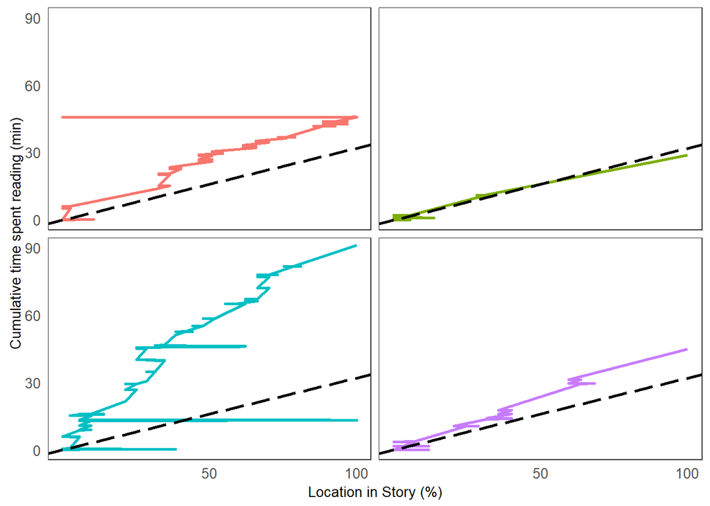

```r
Graph4e
```

```r
# ggsave(
#     "Fig_ProgressGraphStoryId1b_facets.png",
#     plot = Graph4e,
#     width = 18,
#     height = 18,
#     units = "cm",
#     dpi = 300
# )
```